# IE360 Homework 2

## Intro

In this homework, three time series datasets was obtained from EVDS in order to forecast one of them by using the others as regressors. The question of interest is “What is the effect of consumer loan interest rates and EUR/TRY exchange rates on the consumer price index of purchase of vehicles?”, the dependent variable being the consumer price index of purchase of vehicles.

Firstly, the reason why EUR/TRY exchange rates was chosen (instead of USD/TRY) is the fact that although American or Japanese vehicles are also widely used in Turkey, European brands are generally chosen by Turkish customers; hence, EUR/TRY exchange rates are sort of more deterministic than USD/TRY exchange rates. Secondly, in Turkey, most of the people purchase vehicles by loans as they do not have enough cash at hand at the time. Therefore, the interest rates on consumer loans are though to be relevant to the demand of vehicles and hence; it was chosen as an independent variable.

The R markdown file of this homework can be found [here](https://bu-ie-360.github.io/spring21-ozdemirezgi/files/HW2/IE360_HW2.Rmd)

The data series that are worked on can be found [here](https://bu-ie-360.github.io/spring21-ozdemirezgi/files/HW2/IE360_HW2_Data.zip)

## The data

```r
library(data.table)
library(forecast)
library(lubridate)
library(parsedate)
library(readxl)
library(ggplot2)
EVDS_3_ <- read_excel("C:/Users/Ezgi-Pc/Downloads/EVDS (3).xlsx")

evds <- EVDS_3_
evds <- evds[-(1:2),]
evds <- evds[-(154:171), ]
names(evds) <- c("Date", "EUR_TRY", "Consumer_Interests", "CPI_Vehicles")
evds <- evds[order(evds$Date),]
```

Although the data of the variables on 04.21 is required not to be used, in order to be able to predict 04.21, the row of 05.21 is erased only and the date column was converted to class “Date”.

```r
evds <- evds[-(149:153),]
evds$Date <- parse_date_time(evds$Date, "%y/%m")
evds$Date <- as.Date(evds$Date, format = "%y-%m-%d", optional = FALSE)
evds <- data.table(evds)
```

### CPI of Vehicles

To observe how the CPI of vehicles changed across time,

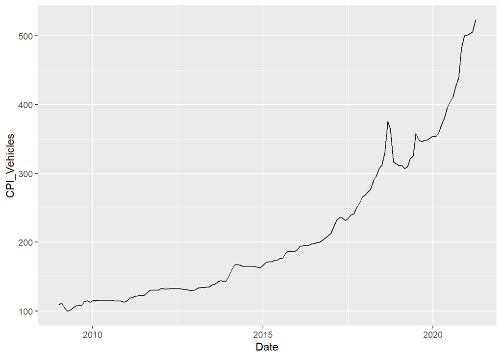

```r
ggplot(evds, aes(x = Date, y = CPI_Vehicles)) + geom_line()
```

As seen above, there is an upward trend in the data with an unexpected increase in 2018. In addition, there is no seasonality observed. The trend component can also be seen by regressing on it as below.

```r
evds[,trend:=1:.N]
reg1 <- lm(CPI_Vehicles~trend, evds)
summary(reg1)
```

```
##
## Call:
## lm(formula = CPI_Vehicles ~ trend, data = evds)
##
## Residuals:
##     Min      1Q  Median      3Q     Max
## -53.851 -34.155  -5.893  23.280 143.588
##
## Coefficients:
##             Estimate Std. Error t value Pr(>|t|)
## (Intercept) 41.93655    7.07251    5.93  2.1e-08 ***
## trend        2.28112    0.08235   27.70  < 2e-16 ***
## ---
## Signif. codes:  0 '***' 0.001 '**' 0.01 '*' 0.05 '.' 0.1 ' ' 1
##
## Residual standard error: 42.8 on 146 degrees of freedom
## Multiple R-squared:  0.8401, Adjusted R-squared:  0.839
## F-statistic: 767.3 on 1 and 146 DF,  p-value: < 2.2e-16
```

Here, as the p-value is very close to zero, the statistically significantness of the trend component can be seen. The model has adjusted R-squared value 0.84, which means that the model is pretty valid.

### Consumer Loan Interest Rates

The graph of consumer loan interest rates across time is

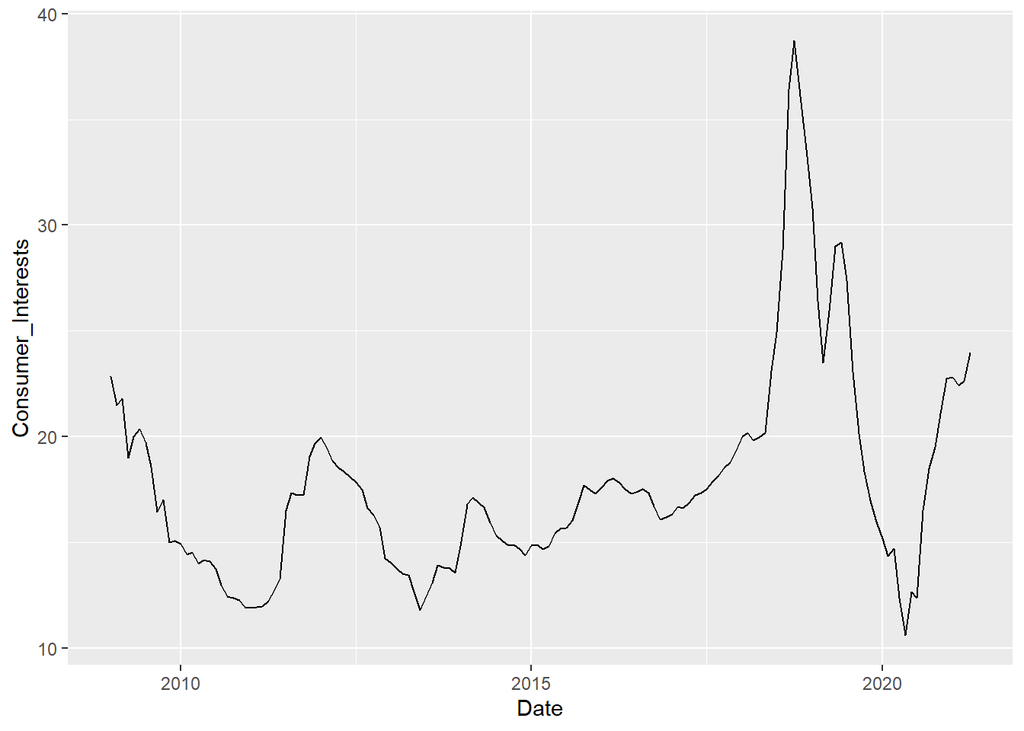

```r
evds$Consumer_Interests <- as.numeric(evds$Consumer_Interests)
ggplot(evds, aes(x = Date, y = Consumer_Interests)) +
  geom_line()
```

The interest rates fluctuate over time but there is no seasonality or trend is seen on the graph. There is a significant increase in 2018 again, possibly in order to mitigate the depreciation of TRY against USD that resulted from Priest Brunson Crisis.

### EUR/TRY Exchange Rates

The graph of EUR/TRY exchange rates across time is

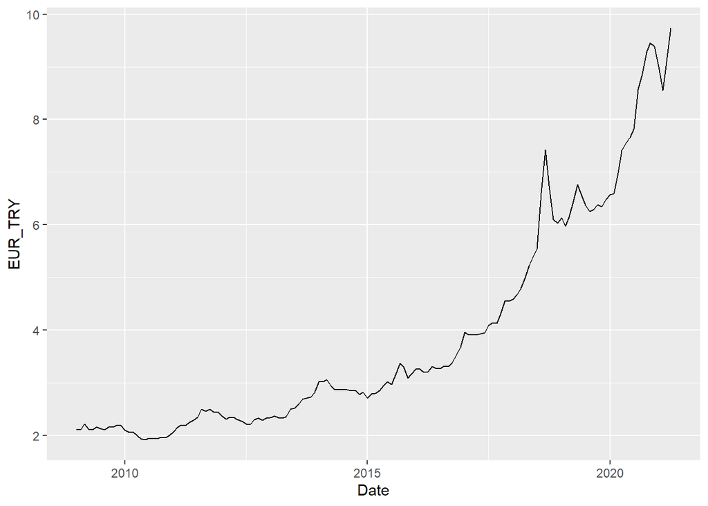

```r
evds$EUR_TRY<-as.numeric(evds$EUR_TRY)
ggplot(evds, aes(x = Date, y = EUR_TRY)) + geom_line()
```

Like CPI of vehicles, there is no seasonality observed but there is definitely an upward trend. In addition, the significant increase in 2018 can be seen here, too.

## The Regression

The regression where the CPI is the dependent variable and its trend, EUR/TRY exchange rates and consumer loan interest rates are predictors is below.

```r
reg2 <- lm(CPI_Vehicles ~ trend + EUR_TRY + Consumer_Interests, evds)
summary(reg2)
```

```
##
## Call:
## lm(formula = CPI_Vehicles ~ trend + EUR_TRY + Consumer_Interests,
##     data = evds)
##
## Residuals:
##     Min      1Q  Median      3Q     Max
## -35.930  -4.609   0.476   5.299  59.344
##
## Coefficients:
##                    Estimate Std. Error t value Pr(>|t|)
## (Intercept)        14.00844    3.80343   3.683 0.000325 ***
## trend               0.42593    0.05155   8.262 8.52e-14 ***
## EUR_TRY            43.07975    1.11651  38.584  < 2e-16 ***
## Consumer_Interests -0.03459    0.23681  -0.146 0.884065
## ---
## Signif. codes:  0 '***' 0.001 '**' 0.01 '*' 0.05 '.' 0.1 ' ' 1
##
## Residual standard error: 12.22 on 144 degrees of freedom
## Multiple R-squared:  0.9871, Adjusted R-squared:  0.9869
## F-statistic:  3684 on 3 and 144 DF,  p-value: < 2.2e-16
```

On the other hand, to check the residuals,

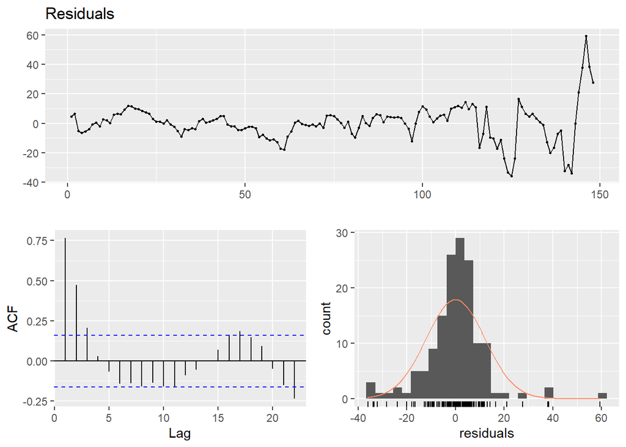

```
##
##  Breusch-Godfrey test for serial correlation of order up to 12
##
## data:  Residuals
## LM test = 99.33, df = 12, p-value = 7.531e-16
```

```r
checkresiduals(reg2, lag = 12)
```

## Prediction

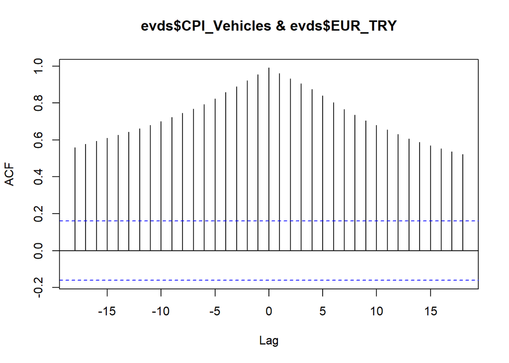

```r
ccf(evds$CPI_Vehicles, evds$EUR_TRY)
```

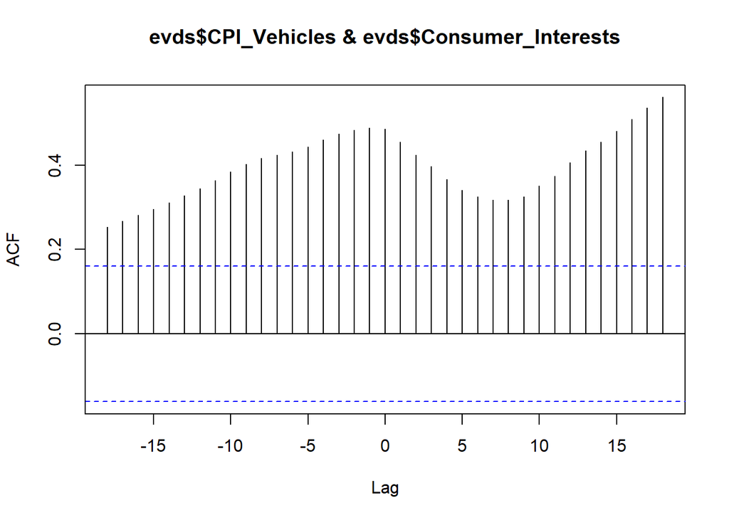

```r
ccf(evds$CPI_Vehicles, evds$Consumer_Interests)
```

Firstly, for EUR/TRY exchange rates, all the lags have strong cross-correlation. Since the best lag is 0, the second best option, -1, was chosen. Secondly, for interest rates, all the lags have strong cross-correlation again. Here, lag 15 was chosen, as it is one of the lags to have the highest autocorrelation.

The regression with the lags as regressors is down below.

```r
reg3 <- lm(evds$CPI_Vehicles ~ lag(evds$EUR_TRY, -1) + lag(evds$Consumer_Interests, 15))
summary(reg3)
```

```
##
## Call:
## lm(formula = evds$CPI_Vehicles ~ lag(evds$EUR_TRY, -1) + lag(evds$Consumer_Interests,
##     15))
##
## Residuals:
##     Min      1Q  Median      3Q     Max
## -47.932  -9.320   0.012  10.799  53.061
##
## Coefficients:
##                                  Estimate Std. Error t value Pr(>|t|)
## (Intercept)                       17.4127     4.5747   3.806 0.000207 ***
## lag(evds$EUR_TRY, -1)             51.0639     0.6765  75.477  < 2e-16 ***
## lag(evds$Consumer_Interests, 15)  -0.1796     0.2857  -0.628 0.530696
## ---
## Signif. codes:  0 '***' 0.001 '**' 0.01 '*' 0.05 '.' 0.1 ' ' 1
##
## Residual standard error: 14.79 on 145 degrees of freedom
## Multiple R-squared:  0.981,  Adjusted R-squared:  0.9808
## F-statistic:  3752 on 2 and 145 DF,  p-value: < 2.2e-16
```

Although there was a strong cross-correlation, the lag of the interest rates still is not statistically significant. On the other hand, the exchange rates are statistically significant. Here, the adjusted R-squared value is 0.98, making the model a good one.

Also, the residual plots of this regression are down below.

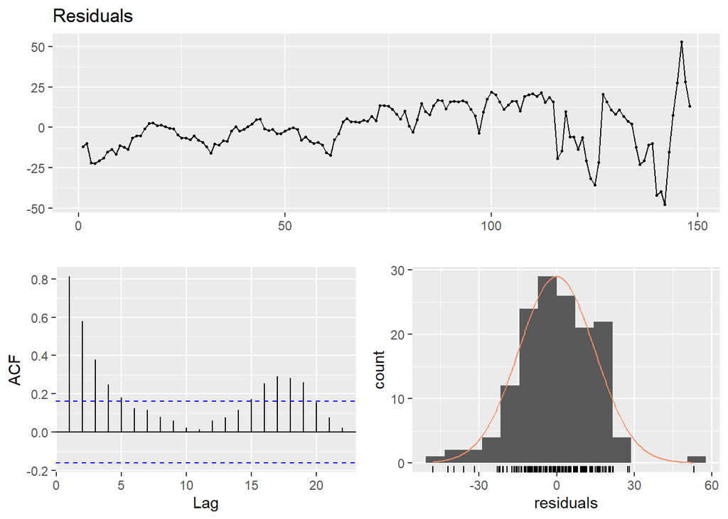

```
##
##  Breusch-Godfrey test for serial correlation of order up to 10
##
## data:  Residuals
## LM test = 103.25, df = 10, p-value < 2.2e-16
```

```r
checkresiduals(reg3)
```

The result are not so different than the previous regression. There are some differences though, the mean does not diverge much from zero until the ends, there are more spikes in the autocorrelation plot and the residuals seem to have a normal distribution more.

Unfortunately, as mentioned in the beginning, the row of 04.21 was needed to be kept in order to be able to predict the CPI of vehicles of 04.21

```r
predict(reg3, evds[is.na(CPI_Vehicles) == TRUE])
```

```
##        1        2        3        4        5        6        7        8
## 121.3034 121.5887 126.7945 122.0997 121.6441 123.9702 122.7227 121.7433
##        9       10       11       12       13       14       15       16
## 124.6336 124.9938 127.3399 126.7558 121.8218 120.2127 120.7830 116.9922
##       17       18       19       20       21       22       23       24
## 113.9026 112.8218 114.8310 114.2336 114.4352 115.7909 115.4272 117.3546
##       25       26       27       28       29       30       31       32
## 121.1701 125.5492 127.7307 126.8837 129.9647 132.1350 134.5915 141.9475
##       33       34       35       36       37       38       39       40
## 140.1149 141.9233 138.9322 139.0937 134.9665 132.1177 134.0506 133.7383
##       41       42       43       44       45       46       47       48
## 131.8324 130.3157 127.6791 127.1907 132.1314 133.3734 131.5733 133.9985
##       49       50       51       52       53       54       55       56
## 134.4477 135.9067 134.7193 134.2579 135.9864 142.8814 144.0571 147.9172
##       57       58       59       60       61       62       63       64
## 152.2810 153.4778 154.2975 158.8739 169.0049 168.5740 170.8837 164.4223
##       65       66       67       68       69       70       71       72
## 161.1988 161.3941 161.5435 161.6090 160.2840 160.9907 157.1008 158.9159
##       73       74       75       76       77       78       79       80
## 153.4440 157.2010 157.9938 160.4542 165.5413 169.1553 166.3029 176.2620
##       81       82       83       84       85       86       87       88
## 186.7121 182.6742 172.0269 176.1575 181.0721 180.8020 177.9041 178.2956
##       89       90       91       92       93       94       95       96
## 183.5307 181.6556 181.3193 183.8368 183.6536 187.3454 195.0038 202.4842
##       97       98       99      100      101      102      103      104
## 216.9685 214.1206 214.3828 214.0460 215.1207 215.9314 223.1865 225.7867
##      105      106      107      108      109      110      111      112
## 225.4377 234.0819 246.3597 246.4062 248.2672 252.4196 258.2136 268.3177
##      113      114      115      116      117      118      119      120
## 280.4583 289.3635 296.0956 349.5949 390.0079 354.7171 322.7308 319.7403
##      121      122      123      124      125      126      127      128
## 325.0254 317.7804 327.6410 341.9916 357.7669 346.9937 337.7241 332.7238
##      129      130      131      132      133      134      135      136
## 335.1657 340.2082 338.0999 345.4819 350.4330 351.5446 371.6402 393.9162
##      137      138      139      140      141      142      143      144
## 401.5260 406.4114 414.5611 452.3565 466.5566 487.4620 496.5481 492.5179
##      145      146      147      148
## 473.3032 450.2987 477.5855 510.1570
```

As the data of 04.21 is actually available, it is clearly seen that the prediction is not correct since it is 523.13 in the actual data. This may be because of the probability of having a spurious regression that underestimated the values of CPI of vehicles.

## Conclusion

In conclusion, the CPI of the vehicles can be said to have a strong correlation with EUR/TRY exchange rates, as Turkey mainly imports vehicles and these vehicles are mostly from Europe. Although consumer loan interest rates determine the demands for those loans, which are the key source for purchasing vehicles in Turkey, the interest rates do not seem to effect the prices as much as the exchange rates do. This can be because of a possible multicollinearity between the exchange rates and the interest rates, or the fact that prices are determined according to the exchange rates, more than demands for the vehicles.

The regression model could not predict the 04.21 data of the CPI of vehicles. The fact that the model was not a very good one (although the adjusted R-squared values were always so close to 1, the regression can be spurious) may be the main reason for this failure.